# Life Expectancy

H. Suzuki

2023-12-20

> We study life expectancy using tidyverse and WDI packages.

> As the first attempt, we select the following world development indicators:
> - Life expectancy at birth, total: SP.DYN.LE00.IN [[Link](https://data.worldbank.org/indicator/SP.DYN.LE00.IN)]
> - Fertility rate, total (births per woman): SP.DYN.TFRT.IN [[Link](https://data.worldbank.org/indicator/SP.DYN.TFRT.IN)]
> - Population, total: SP.POP.TOTL [[Link](https://data.worldbank.org/indicator/SP.POP.TOTL)]

> Please learn how we use `WDI` to import, `select`, `filter`, `distinct`, `drop_na` to manipulate, and `ggplot` to visualize the data.

Step 0-1. If not installed, run only once.

```r
install.packages("tidyverse")
install.packages("WDI")
```

Step 0-2. Create data directory, run only once. You can also create a new directory (or folder) from the Files tab in the right below pane.

```r
dir.create("data")
```

Step 0-3. Change the system language if your system language is not English.

```r
Sys.setenv(LANG = "en")
```

Step 1. Load the packages.

```r
library(tidyverse)
library(WDI)
```

Step 2. Download data. See Help. (Put WDI in the search window under the Help tab in the right below pane. Run only once.

```r
df_wdi_life <- WDI(indicator = c(life_expectancy = "SP.DYN.LE00.IN",
                             fertility_rate = "SP.DYN.TFRT.IN",
                             population = "SP.POP.TOTL"),
                   extra = TRUE)
```

Step 3. Write the data. Run only once.

```r
write_csv(df_wdi_life, "data/wdi_life.csv")
```

Step 4. Read the data from the data directory.

```r
df_wdi_life <- read_csv("data/wdi_life.csv")
```

Step 5. Head, showing the first 6 rows.

```r
head(df_wdi_life)
```

| country | iso2c | iso3c | year | status | lastupdated | life_expectancy | fertility_rate | population | region | capital | longitude | latitude | income | lending |
| --- | --- | --- | --- | --- | --- | --- | --- | --- | --- | --- | --- | --- | --- | --- |
| Afghanistan | AF | AFG | 2014 | NA | 2023-10-26 | 62.545 | 5.560 | 32716210 | South Asia | Kabul | 69.1761 | 34.5228 | Low income | IDA |
| Afghanistan | AF | AFG | 1971 | NA | 2023-10-26 | 37.923 | 7.432 | 11015857 | South Asia | Kabul | 69.1761 | 34.5228 | Low income | IDA |
| Afghanistan | AF | AFG | 2006 | NA | 2023-10-26 | 58.684 | 6.722 | 25442944 | South Asia | Kabul | 69.1761 | 34.5228 | Low income | IDA |
| Afghanistan | AF | AFG | 2013 | NA | 2023-10-26 | 62.417 | 5.696 | 31541209 | South Asia | Kabul | 69.1761 | 34.5228 | Low income | IDA |
| Afghanistan | AF | AFG | 1995 | NA | 2023-10-26 | 52.544 | 7.712 | 16418912 | South Asia | Kabul | 69.1761 | 34.5228 | Low income | IDA |
| Afghanistan | AF | AFG | 2005 | NA | 2023-10-26 | 58.361 | 6.905 | 24411191 | South Asia | Kabul | 69.1761 | 34.5228 | Low income | IDA |

Step 6. Structure, showing all the columns, i.e., variables.

```r
str(df_wdi_life)
```

```
spc_tbl_ [16,758 × 15] (S3: spec_tbl_df/tbl_df/tbl/data.frame)
 $ country        : chr [1:16758] "Afghanistan" "Afghanistan" "Afghanistan" "Afghanistan" ...
 $ iso2c          : chr [1:16758] "AF" "AF" "AF" "AF" ...
 $ iso3c          : chr [1:16758] "AFG" "AFG" "AFG" "AFG" ...
 $ year           : num [1:16758] 2014 1971 2006 2013 1995 ...
 $ status         : logi [1:16758] NA NA NA NA NA NA ...
 $ lastupdated    : Date[1:16758], format: "2023-10-26" "2023-10-26" ...
 $ life_expectancy: num [1:16758] 62.5 37.9 58.7 62.4 52.5 ...
 $ fertility_rate : num [1:16758] 5.56 7.43 6.72 5.7 7.71 ...
 $ population     : num [1:16758] 32716210 11015857 25442944 31541209 16418912 ...
 $ region         : chr [1:16758] "South Asia" "South Asia" "South Asia" "South Asia" ...
 $ capital        : chr [1:16758] "Kabul" "Kabul" "Kabul" "Kabul" ...
 $ longitude      : num [1:16758] 69.2 69.2 69.2 69.2 69.2 ...
 $ latitude       : num [1:16758] 34.5 34.5 34.5 34.5 34.5 ...
 $ income         : chr [1:16758] "Low income" "Low income" "Low income" "Low income" ...
 $ lending        : chr [1:16758] "IDA" "IDA" "IDA" "IDA" ...
 - attr(*, "spec")=
  .. cols(
  ..   country = col_character(),
  ..   iso2c = col_character(),
  ..   iso3c = col_character(),
  ..   year = col_double(),
  ..   status = col_logical(),
  ..   lastupdated = col_date(format = ""),
  ..   life_expectancy = col_double(),
  ..   fertility_rate = col_double(),
  ..   population = col_double(),
  ..   region = col_character(),
  ..   capital = col_character(),
  ..   longitude = col_double(),
  ..   latitude = col_double(),
  ..   income = col_character(),
  ..   lending = col_character()
  .. )
 - attr(*, "problems")=<externalptr>
```

Step 7. Select columns. Same as `select(c(1,2,4,7,8,9,10,14))` .

```r
df_life <- df_wdi_life |> select(c("country", "iso2c", "year", "life_expectancy", "fertility_rate", "population", "region", "income"))
head(df_life)
```

| country | iso2c | year | life_expectancy | fertility_rate | population | region | income |
| --- | --- | --- | --- | --- | --- | --- | --- |
| Afghanistan | AF | 2014 | 62.545 | 5.560 | 32716210 | South Asia | Low income |
| Afghanistan | AF | 1971 | 37.923 | 7.432 | 11015857 | South Asia | Low income |
| Afghanistan | AF | 2006 | 58.684 | 6.722 | 25442944 | South Asia | Low income |
| Afghanistan | AF | 2013 | 62.417 | 5.696 | 31541209 | South Asia | Low income |
| Afghanistan | AF | 1995 | 52.544 | 7.712 | 16418912 | South Asia | Low income |
| Afghanistan | AF | 2005 | 58.361 | 6.905 | 24411191 | South Asia | Low income |

`7:10 is same as 7, 8, 9, 10`

```r
df_wdi_life |> select(c(1,2,4,7:10,14)) |> identical(df_life)
```

```
[1] TRUE
```

```r
df_wdi_life |> select(
  c("country", "iso2c", "year", "life_expectancy":"region", "income")) |>
  identical(df_life)
```

```
[1] TRUE
```

Step 8. List regions and income levels.

```r
df_life$region |> unique()
```

```
[1] "South Asia"                 "Aggregates"
[3] "Europe & Central Asia"      "Middle East & North Africa"
[5] "East Asia & Pacific"        "Sub-Saharan Africa"
[7] "Latin America & Caribbean"  "North America"
[9] NA
```

```r
df_life$income |> unique()
```

```
[1] "Low income"          "Aggregates"          "Upper middle income"
[4] "Lower middle income" "High income"         NA
[7] "Not classified"
```

Step 9. Aggregates

```r
df_life |> filter(region == "Aggregates") |> distinct(country, iso2c)
```

| country | iso2c |
| --- | --- |
| Africa Eastern and Southern | ZH |
| Africa Western and Central | ZI |
| Arab World | 1A |
| Caribbean small states | S3 |
| Central Europe and the Baltics | B8 |
| Early-demographic dividend | V2 |
| East Asia & Pacific | Z4 |
| East Asia & Pacific (excluding high income) | 4E |
| East Asia & Pacific (IDA & IBRD countries) | T4 |
| Euro area | XC |

[output cut: 32 more lines]

Step 10. Check the countries with NA in region.

```r
df_life |> filter(is.na(region)) |> distinct(country, iso2c)
```

| country | iso2c |
| --- | --- |
| Czechia | CZ |
| High income | XD |
| Latin America & Caribbean | ZJ |
| Low income | XM |
| Lower middle income | XN |
| Not classified | XY |
| Sub-Saharan Africa | ZG |
| Upper middle income | XT |
| Viet Nam | VN |

Step 11. List country names, iso2c’s with their region and income level.

```r
df_life |> filter(region != "Aggregates" | country %in% c("Viet Nam", "Czechia")) |> distinct(country, iso2c, region, income)
```

| country | iso2c | region | income |
| --- | --- | --- | --- |
| Afghanistan | AF | South Asia | Low income |
| Albania | AL | Europe & Central Asia | Upper middle income |
| Algeria | DZ | Middle East & North Africa | Lower middle income |
| American Samoa | AS | East Asia & Pacific | Upper middle income |
| Andorra | AD | Europe & Central Asia | High income |
| Angola | AO | Sub-Saharan Africa | Lower middle income |
| Antigua and Barbuda | AG | Latin America & Caribbean | High income |
| Argentina | AR | Latin America & Caribbean | Upper middle income |
| Armenia | AM | Europe & Central Asia | Upper middle income |
| Aruba | AW | Latin America & Caribbean | High income |

[output cut: 207 more lines]

Step 11. Set groups.

```r
INCOME <- c("Low income", "Lower middle income", "Upper middle income", "High income")
REGION <- c("South Asia", "Europe & Central Asia", "Middle East & North Africa", "East Asia & Pacific", "Sub-Saharan Africa", "Latin America & Caribbean",  "North America")
```

### Visualization

Chart 1. Draw a line graph of the life expectancy at birth of the world.

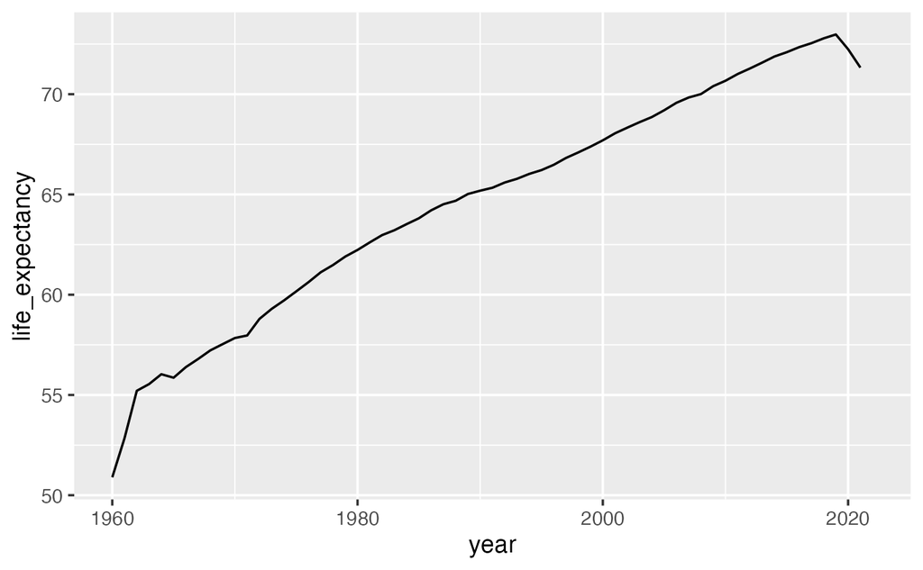

```r
df_life |> filter(country == "World") |>
  ggplot(aes(year, life_expectancy)) + geom_line()
```

Chart 2. Remove rows with missing values and add the chart title.

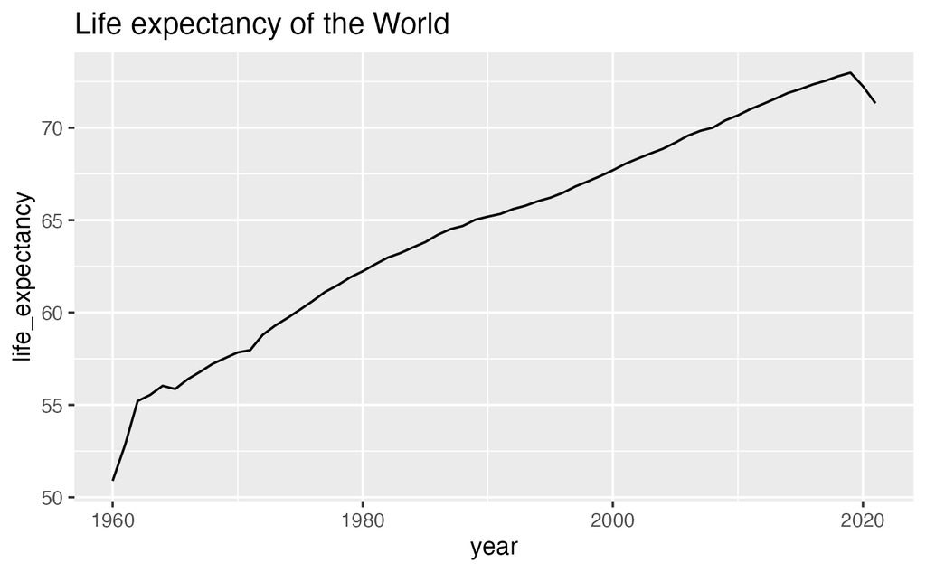

```r
df_life |> filter(country == "World") |> drop_na(life_expectancy) |>
  ggplot(aes(year, life_expectancy)) + geom_line() +
  labs(title = "Life expectancy of the World")
```

Chart 3 Life expectancy of chosen countries with chart title and y-label.

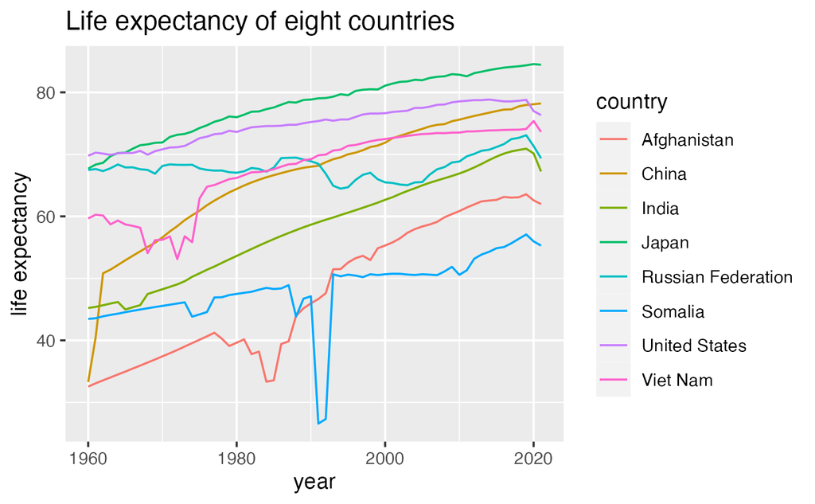

```r
df_life |> filter(country %in% c("Afghanistan", "China", "India", "Japan", "United States", "Viet Nam", "Russian Federation", "Somalia")) |> drop_na(life_expectancy) |>
  ggplot(aes(year, life_expectancy, col = country)) + geom_line() +
  labs(title = "Life expectancy of eight countries", y = "life expectancy")
```

Chart 4. Life expectancy by regions

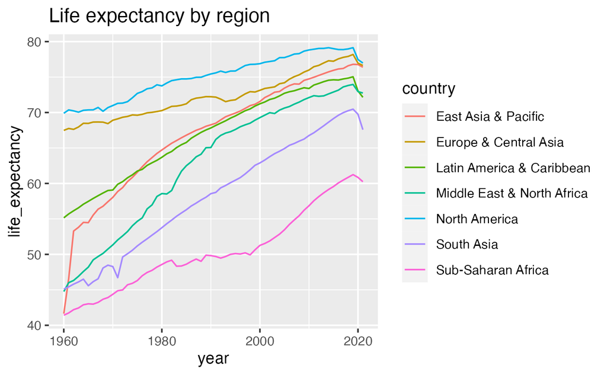

```r
df_life |> filter(country %in% REGION) |> drop_na(life_expectancy) |>
  ggplot(aes(year, life_expectancy, col = country)) + geom_line() +
  labs(title = "Life expectancy by region")
```

Chart 5. Life expectancy by income levels

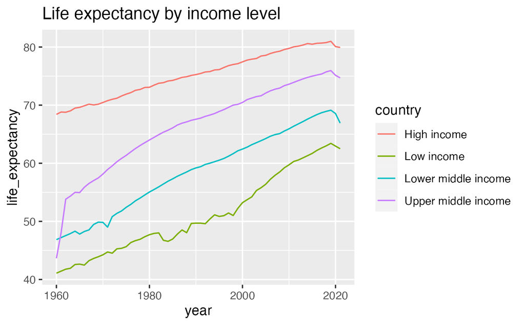

```r
df_life |> filter(country %in% INCOME) |> drop_na(life_expectancy) |>
  ggplot(aes(year, life_expectancy, col = country)) + geom_line() +
  labs(title = "Life expectancy by income level")
```

*Exercise 1. Select a country (or a region name listed under country).*

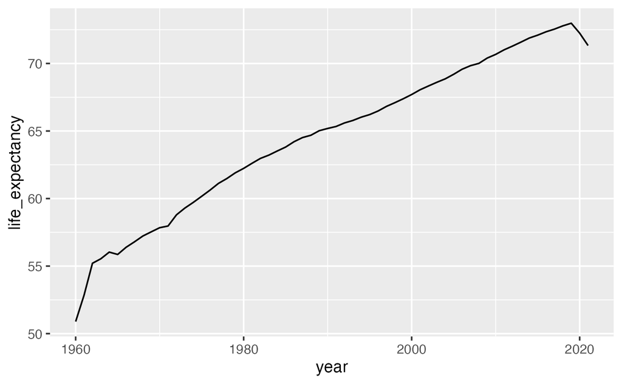

```r
df_life |> filter(country == "World") |> drop_na(life_expectancy) |>
  ggplot(aes(year, life_expectancy)) + geom_line()
```

*Exercise 2. Select countries of your choice*

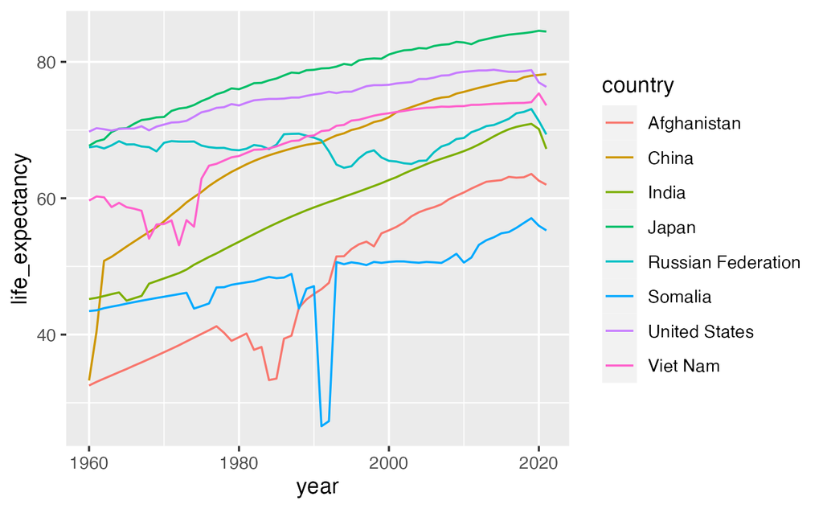

```r
df_life |> filter(country %in% c("Afghanistan", "China", "India", "Japan", "United States", "Viet Nam", "Russian Federation", "Somalia")) |> drop_na(life_expectancy) |>
  ggplot(aes(year, life_expectancy, col = country)) + geom_line()
```

Chart 6. Relation between fertility rate and life expectancy in 2021 by a scatter plot with regions in color.

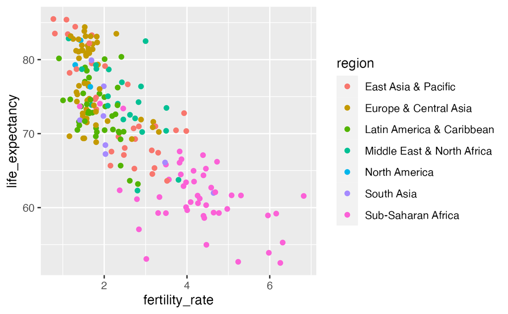

```r
df_life |> filter(year == 2021) |>
  filter(region != "Aggregates") |> drop_na(fertility_rate, life_expectancy) |>
  ggplot(aes(fertility_rate, life_expectancy, col = region)) + geom_point()
```

*Exercise 3. Change the year.*

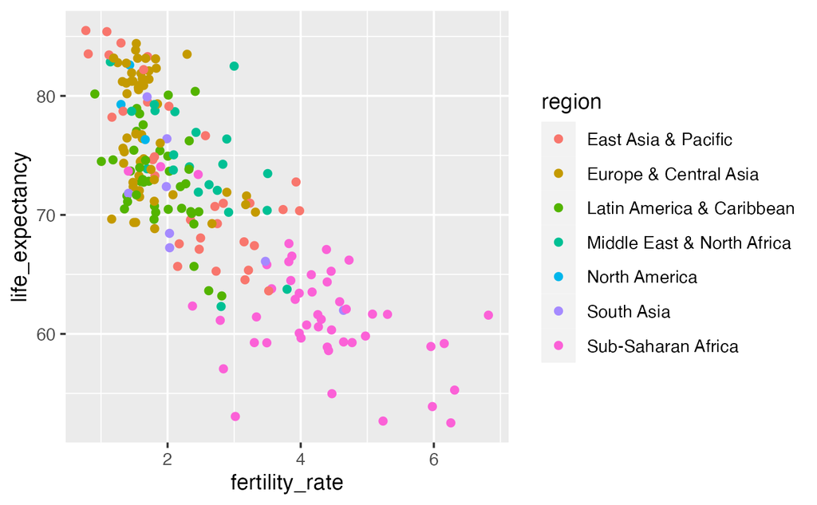

```r
df_life |> filter(year == 2021) |>
  filter(region != "Aggregates") |> drop_na(fertility_rate, life_expectancy) |>
  ggplot(aes(fertility_rate, life_expectancy, col = region)) + geom_point()
```

Chart 7. Relation between fertility rate and life expectancy in 2021 by a scatter plot with regions in color and population in size.

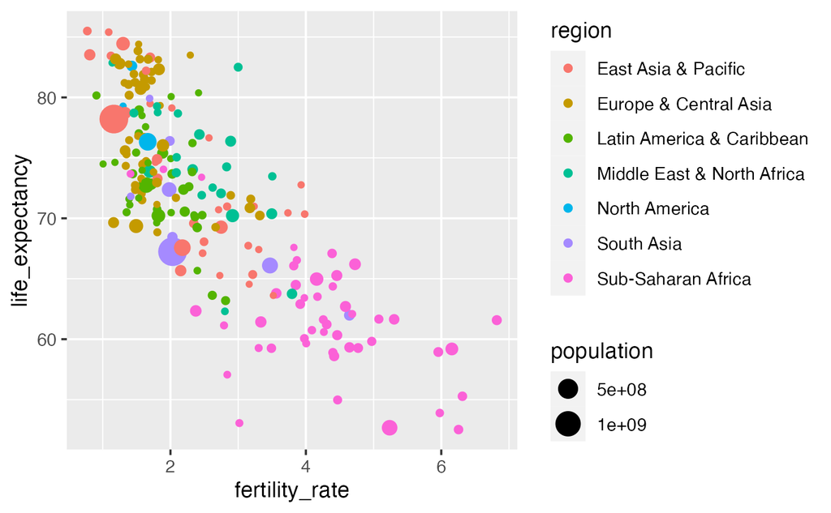

```r
df_life |> filter(year == 2021) |>
  filter(region != "Aggregates") |> drop_na(fertility_rate, life_expectancy) |>
  ggplot(aes(fertility_rate, life_expectancy, col = region, size = population)) + geom_point()
```

*Exercise 4. Change the year.*

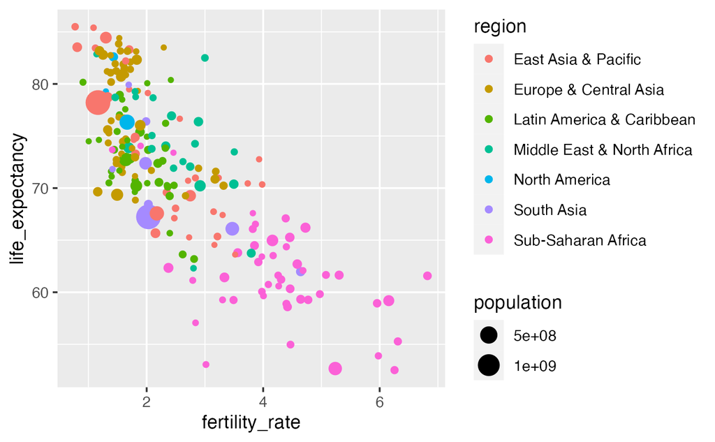

```r
df_life |> filter(year == 2021) |>
  filter(region != "Aggregates") |> drop_na(fertility_rate, life_expectancy) |>
  ggplot(aes(fertility_rate, life_expectancy, col = region, size = population)) + geom_point()
```

## Addendum

The region and the income level of Viet Nuam and Czechia are NA. If you want to revise it, there are two ways to change entries. There is yet another way to be introduced later.

```r
df_life_revised <- df_life
df_life_revised <- df_life_revised |> mutate(
  region = case_when(
    is.na(region) & country == "Viet Nam" ~ "East Asia & Pacific",
    is.na(region) & country == "Czechia" ~ "Europe & Central Asia",
    TRUE ~ region))
df_life_revised |> filter(country %in% c("Viet Nam", "Czechia")) |> distinct(country, region)
```

| country | region |
| --- | --- |
| Czechia | Europe & Central Asia |
| Viet Nam | East Asia & Pacific |

```r
df_life_revised <- df_life
df_life_revised$region[df_life_revised$country == "Viet Nam"] <- "East Asia & Pacific"
df_life_revised$region[df_life_revised$country == "Czechia"] <- "Europe & Central Asia"
df_life_revised |> filter(country %in% c("Viet Nam", "Czechia")) |> distinct(country, region)
```

| country | region |
| --- | --- |
| Czechia | Europe & Central Asia |
| Viet Nam | East Asia & Pacific |